# MG205: Econometrics Theory and Applications

Topic 4: Statistical Inference

José Ignacio González-Rojas

j.i.gonzalez-rojas@lse.ac.uk

London School of Economics and Political Science

## Today We Test Whether Our Estimates Are Real

### Five Core Exercises Build Statistical Inference Skills

**Coverage today:**

- One-sided tests for policy thresholds
- Reading multiple regression output
- Finding bias through coefficient changes
- F-tests when individual tests fail
- Quantifying uncertainty with confidence intervals

**Skills you develop:**

- Choosing appropriate test for research question
- Interpreting standard regression output
- Understanding correlation structure from coefficients
- Recognizing when joint tests needed
- Communicating uncertainty professionally

# **Exercise 1:** Point Estimates Insufficient When Thresholds Matter

## Bed Nets Reduce Malaria By 4 Percentage Points

### Programme Cannot Proceed Despite Point Estimate Exceeding Threshold

#### Field experiment in sub-Saharan Africa

$$\widehat{\text{malaria}}_{i} = \underset{(0.06)}{0.17} - \underset{(0.02)}{0.04} \cdot \text{bednets}_{i}$$

where $\text{malaria}_{i}$ is household incidence rate (0-1 scale) and $\text{bednets}_{i} = 1$ if received

- **Policy threshold:** Cost-effective only if reduction $\geq 3$ percentage points

Should programme proceed?

## One-Sided Test Required When Policy Has Directional Threshold

$$H_0: \beta_{\text{bednets}} = -0.03 \quad \text{vs} \quad H_1: \beta_{\text{bednets}} < -0.03$$

$$t = \frac{-0.04 - (-0.03)}{0.02} = -0.5$$

- **Critical value:** $-1.64$ (one-sided, 5% level)
- **Test statistic:** $-0.5 > -1.64$
- **Decision:** Fail to reject $H_0$
- **Answer:** Programme should **not** proceed

## Large Standard Error Prevents Rejection

### Uncertainty Around Estimate Too Large

**95% Confidence interval:** $[-0.04 \pm 1.96(0.02)] = [-0.079, -0.001]$

**True effect could be:**

- As small as 0.1% (essentially nothing)
- As large as 7.9% (very effective)

**Problem:** Cannot rule out values below 3% threshold

Standard error $(0.02)$ large relative to distance from threshold $(0.01)$

# **Exercise 2:** Sales and Profitability Determine CEO Salary

$$\widehat{\log(\text{salary})}_{i} = \underset{(0.29)}{4.3} + \underset{(0.03)}{0.27} \log(\text{sales})_{i} + \underset{(0.003)}{0.018} \cdot \text{ROE}_{i} + \underset{(0.0003)}{0.0005} \cdot \Delta\text{ROE}_{i}$$

Summary of results

| Variable | Coefficient | t-statistic | Decision at 5% |
| --- | --- | --- | --- |
| $\log(\text{sales})$ | 0.27 | 9.0 | Reject $H_0$ ✓ |
| $\text{ROE}$ | 0.018 | 6.0 | Reject $H_0$ ✓ |
| $\Delta\text{ROE}$ | 0.0005 | 1.67 | Fail to reject ✗ |

Recent performance changes do not affect current salary

## Elasticity Interpretation for Log-Log Specification

$$\hat{\beta}_{\log(\text{sales})} = 0.27$$

### Direct interpretation

- 1% increase in sales associates with 0.27% increase in salary

### Example

- Sales increase 10% → salary increases 2.7%

## Semi-Elasticity for Log-Level Specification

$$\hat{\beta}_{\text{ROE}} = 0.018$$

### Unit matters

- One unit of ROE is entire range from 0 to 1
- Both holding other variables constant

## Firm Size Affects CEO Salary

### Test Result for $H_0: \beta_{\log(\text{sales})} = 0$

$$t = \frac{0.27 - 0}{0.03} = 9.0$$

- **Critical value:** $t_{205,0.025} = 1.96$ (two-sided)
- **Test statistic:** $|9.0| > 1.96$
- **Decision:** Reject $H_0$ at 5% level
- **Interpretation:** Firm size affects CEO salary

## Return on Equity Affects CEO Salary

### Test Result for $H_0: \beta_{\text{ROE}} = 0$

$$t = \frac{0.018 - 0}{0.003} = 6.0$$

- **Critical value:** 1.96
- **Test statistic:** $|6.0| > 1.96$
- **Decision:** Reject $H_0$ at 5% level

## Recent Performance Changes Do Not Affect Salary

### Test Result for $H_0: \beta_{\Delta\text{ROE}} = 0$

$$t = \frac{0.0005 - 0}{0.0003} = 1.67$$

- **Critical value:** 1.96
- **Test statistic:** $|1.67| < 1.96$
- **Decision:** Fail to reject $H_0$ at 5% level

Would not include $\Delta\text{ROE}$ in model

## Sample Size Already Accounted For

### Standard Errors Reflect Sample Size Automatically

**Incorrect claim:** “Sample of 209 too small to conclude anything”

**Why wrong:**

$$\text{Var}(\hat{\beta}_j) = \frac{\sigma^2}{n \cdot \text{Var}(x_j)(1 - R_j^2)}$$

Sample size $n$ in denominator

**Evidence:** Despite $n = 209$, we rejected $H_0$ for firm size with $t = 9$

# **Exercise 3:** Coefficient Sign Flip Reveals Negative $x$-$z$ Correlation

## Adding Control Variable Changes Sign From Positive to Negative

### Simple regression

$$\hat{y}_{i} = 0.02 + 0.02 \cdot x_{i}$$

### Multiple regression

$$\hat{y}_{i} = 0.34 - 0.07 \cdot x_{i} - 0.50 \cdot z_{i}$$

What is sign of correlation between $x$ and $z$?

## Three-Step Sign Identification

### Correlation between $x$ and $z$ is **negative**

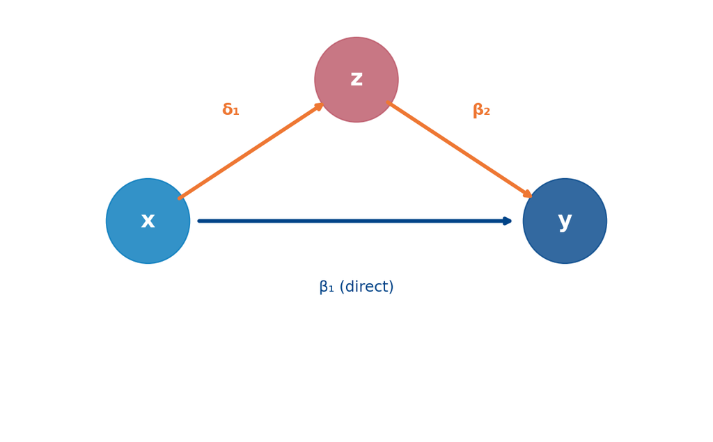

OVB

# **Exercise 7:** Confidence Intervals Quantify Uncertainty Around Estimates

## Work-Sleep Trade-off Study

### Construct 95% confidence intervals

$$\begin{align*}
\widehat{\text{sleep}}_{i} &= 3672 - \underset{(0.02)}{0.152} \cdot \text{work}_{i} - \underset{(7.14)}{11.2} \cdot \text{education}_{i} \\
&- 20.4 \cdot \log(\text{wage})_{i} + 0.80 \cdot \text{age}_{i}
\end{align*}$$

- All variables in minutes per week, $n = 532$ lawyers

## Work Coefficient Significant, Education Not

### If CI includes zero, variable not significant at that confidence level

**Work coefficient:**

- $$\begin{align*}
  &[-0.152 \pm 1.96(0.02)] \\
  =& [-0.191, -0.113]
  \end{align*}$$
- Interval excludes zero
- Significant at 5% level

**Education coefficient:**

- $$\begin{align*}
  &[-11.2 \pm 1.96(7.14)] \\
  =& [-25.19, 2.79]
  \end{align*}$$
- Interval includes zero
- Not significant at 5% level

## Narrower Intervals Require Lower Confidence

### Cannot simultaneously maximize precision and confidence without more data

$$\text{95\% CI: } [-0.191, -0.113] \quad \text{(width: 0.078)}$$
$$\text{90\% CI: } [-0.185, -0.119] \quad \text{(width: 0.066)}$$

# **Exercise 9:** Individual Tests Fail But Joint Test Rejects

## Multicollinearity Creates Paradox

### Variables jointly significant but neither individually significant

**Testing tenure variables in Japanese CEO salary regression ($n=100$):**

#### F-test result

- $F = 4.43 > 3.08$ → Reject $H_0$ at 5% level

#### Individual $p$-values

- Firm tenure: $p = 0.27$ → Fail to reject at 5%
- CEO tenure: $p = 0.35$ → Fail to reject at 5%

## Correlated Regressors Inflate Individual Standard Errors

### When firm tenure and CEO tenure highly correlated

$$\text{SE}(\hat{\beta}_j) = \sqrt{\frac{\hat{\sigma}^2}{n\widehat{\text{Var}(x_{j})}(1 - R_j^2)}}$$

- $R_j^2$ large → $(1 - R_j^2)$ small → $\text{SE}(\hat{\beta}_j)$ large → $t$-statistics small
  - Individual tests fail

## F-Test Unaffected By Multicollinearity

### Does not use individual standard errors

$$F = \frac{(\text{SSR}_r - \text{SSR}_{ur})/q}{\text{SSR}_{ur}/(n-k-1)}$$

- Tests whether both together reduce SSR
- $\text{SSR}_r - \text{SSR}_{ur} = 1.58$ substantial
  - Joint test succeeds

## Long-serving CEOs usually have long firm tenure

### Economic Interpretation

- Cannot separate individual effects
- But together they capture something about experience

Use F-tests when testing multiple related variables

# Synthesis

## Four Essential Lessons

### What We Learned About Statistical Inference

1. **One-sided tests when direction matters:**
   - Use when policy has threshold
   - Test against relevant null
2. **Standard workflow for regression output:**
   - Interpret coefficients
   - Test each coefficient
   - Standard errors reflect sample size
3. **Omitted variable bias reveals correlation structure:**
   - Sign changes indicate correlation sign
4. **F-tests detect joint importance:**
   - Individual tests can fail when regressors correlated

## Next Week: Functional Forms and Interpretation

### From Linear Models to Flexible Specifications

**What we cover:**

- Log transformations and elasticity interpretation
- Quadratic and polynomial terms for non-linear relationships
- Interaction effects between variables

**Why it matters:**

- Real relationships rarely perfectly linear
- Different specifications have different interpretations
- Misspecification creates bias

Functional form choice as important as variable selection

# Appendix

## **Exercise 5:** Why $t$-distribution not Normal

- Under Assumptions 1-7: $\hat{\beta}_j \sim N\left(\beta_j, \frac{\sigma}{\sqrt{n\cdot\text{Var}(x_{j})(1-R_{j}^2)}}\right)$
- If we knew $\sigma^2$: $\frac{\hat{\beta}_j - \beta_j}{\frac{\sigma}{\sqrt{n\cdot\text{Var}(x_{j})(1-R_{j}^2)}}} \sim N(0,1)$
- But $\sigma^2$ is unknown, so we estimate in terms of observables
  - $\hat{\sigma}^2 = \frac{1}{n-k-1}\sum_{i=1}^{n}\hat{\varepsilon}_{i}^2$
  - $\frac{(n-k-1)\hat{\sigma}^2}{\sigma^2} \sim \chi^2_{n-k-1}$ (independent of $\hat{\beta}_j$)
- By definition of t-distribution:
  $$\begin{align*}
  t &= \frac{Z}{\sqrt{\chi^2_{n-k-1}/(n-k-1)}} \\
  &= \frac{\hat{\beta}_j - \beta_j}{\text{SE}(\hat{\beta}_j)} \sim t_{n-k-1}
  \end{align*}$$

Heavier tails account for additional uncertainty from estimating $\sigma^2$

## **Exercise 6:** Testing Joint Significance of Firm and CEO Tenure

### Restricted model

$$\begin{align*}
\widehat{\log(\text{salary})} &= 4.4 + 0.11\log(\text{sales}) \\
&+ 0.19\log(\text{market value}) \\
&- 0.014 \cdot \text{profit}
\end{align*}$$

- $\text{SSR}_r = 18.34$

### Unrestricted model

$$\begin{align*}
\widehat{\log(\text{salary})} &= 4.2 + 0.12\log(\text{sales}) \\
&+ 0.19\log(\text{market value}) \\
&- 0.001 \cdot \text{profit} \\
&- 0.002 \cdot \text{tenure firm} \\
&+ 0.02 \cdot \text{tenure CEO}
\end{align*}$$

- $\text{SSR}_{ur} = 16.76$

## **Exercise 6:** Testing Joint Significance of Firm and CEO Tenure

### Hypotheses

- $H_0: \beta_{\text{tenure firm}} = 0 \text{ AND } \beta_{\text{tenure CEO}} = 0$
- $H_1:$ at least one $\neq 0$

### Test statistic

$$F = \frac{(18.34 - 16.76)/2}{16.76/94} = 4.43 > 3.08$$

Reject $H_0$ at 5% level

## **Exercise 11:** Testing Different Null Values

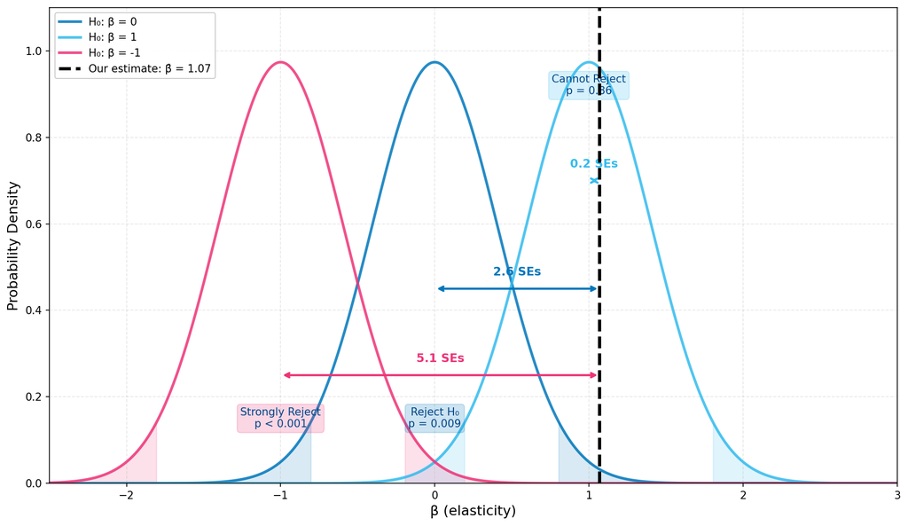

## **Exercise 13:** Comprehensive Practice

$$\begin{align*}
\widehat{\log(\text{salary})}_{i} &= 4.5 + 0.18 \log(\text{sales})_{i} + 0.09 \log(\text{market value})_{i} \\
&- 0.002 \cdot \text{profit}_{i} - 0.09 \cdot \text{tenure firm}_{i} + 0.02 \cdot \text{tenure CEO}_{i}
\end{align*}$$

1. Interpret coefficients: 0.18 is elasticity, -0.09 is semi-elasticity
2. Significant at 5%: sales, market value, both tenure variables (all $p < 0.05$)
3. 95% CI for firm tenure: $[-0.09 \pm 1.96(0.04)] = [-0.168, -0.012]$
4. Do F-test: $H_0: \beta_{\text{profit}} = 0$ AND $\beta_{\text{tenure CEO}} = 0$